# PulseWaveform Tutorial

Simon Williamson

06/07/2022

This tutorial will use a sample PPG time series to demonstrate the PulseWaveform pipeline for PPG feature extraction and running of the Hybrid Excess and Decay (HED) model (see the [ReadMe](https://github.com/stw32/PulseWaveform) for an introduction to the model and pipeline). The sample data is a two-minute segment of raw data outputted by a BioRadio device at 75 Hz, recorded during rest.

# Initial setup

### Install PulseWaveform

If not done so already, install the PulseWaveform package with:

```r
devtools::install_github(repo = 'stw32/PulseWaveform')
```

### Load required packages:

These packages will need to be installed first. All are available on [CRAN](https://cran.r-project.org) and can be installed with install.packages(), other than SplinesUtils which is available [here](https://github.com/ZheyuanLi/SplinesUtils).

```r
library(tidyverse)
library(splines2)
library(pracma)
library(SplinesUtils)
library(spectral)
library(DescTools)
library(zoo)
library(readr)
library(PulseWaveform)
```

### Select starting parameters

In this case we know the sampling rate of Bioradio data (75 hz), and that most primary (but not secondary) PPG peaks in the first derivative are above 0.8 on the y-axis (this is important for proper peak detection). We also wish to visualise the segmented waveforms, and how the extracted fiducial points ‘OSND’ vary across the sample (both plotting parameters are therefore set to true):

```r
samplingRate <- 75
pk_thrshd <- 0.8
plot_aligned_waves <- TRUE
plot_osnd <- TRUE
```

Following this we will select parameters for running the model. For this tutorial we will run the model with the recommended number of simplex iterations (20000). If all beats in the sample are to be modelled (recommended as default), ‘all_beats’ should be set to TRUE. For the purposes of this example we will run only a subset as defined by the ‘batch_number’ and ‘beats_in’ parameters.

‘beats_in’ defines the number of beats to be optimised with some shared parameters (see [ReadMe](https://github.com/stw32/PulseWaveform)). It is effectively a way to alter the trade-off between consistency of model fits (and therefore robustness) vs goodness of fit. In this case we will set it to 2, meaning that beats will be modelled in groups of two with shared parameters within pairs. ‘batch_number’ defines the number of groups of beats to model. We will set it to 6 here, meaning that 6x2 (12) waves will be modelled in total.

```r
run_hed <- TRUE
simplex_iterations <- 20000
all_beats <- FALSE
batch_number <- 6
beats_in <- 2
```

### Download sample data

Download the sample data to a temporary directory and then load into R:

```r
tmpDir = tempdir(check = TRUE)
download.file("https://github.com/stw32/PulseWaveform/blob/main/Example%20Data/example_PPG_time_series.csv?raw=true",
              destfile = file.path(tmpDir, "sample_data.csv"))
data <- read.csv(file.path(tmpDir, "sample_data.csv"), header = T)
```

### Define output folder

Next we define the output folder for all extracted features and segmented waveforms the pipeline will generate:

```r
AllOutputs <- list()
```

# Preprocessing

First duplicate data points are removed from the data, and the undetrending algorithm inherent to Bioradio hardware is reversed. The raw data is assigned to a dataframe ‘ppg’, and an initial attempt at detecting peaks in the first derivative is made (to be refined later).

```r
undetrended_data <- data.frame(preproc(dat=data))
```

```
## [1] "Deduplicating data..."
## [1] "Removing DC blocker..."
## [1] "Done"
```

```r
ppg <- undetrended_data
ppg <- data.frame(
  time = (0:(nrow(ppg)-1)) / samplingRate,
  ppg = ppg[,1]
)
names(ppg)[1] <- "time (s)"
names(ppg)[2] <- "Detrended"


n <- dim(ppg)[1]
vpg <- ppg[2:n,2] - ppg[1:(n-1),2]
beat <- data.frame(ppg[which(vpg[1:(n-1)] < pk_thrshd & vpg[2:n] >= pk_thrshd),1])
rm(vpg)
undetrended <- ppg[, 2]
```

The preprocessed time series can now be visualised:

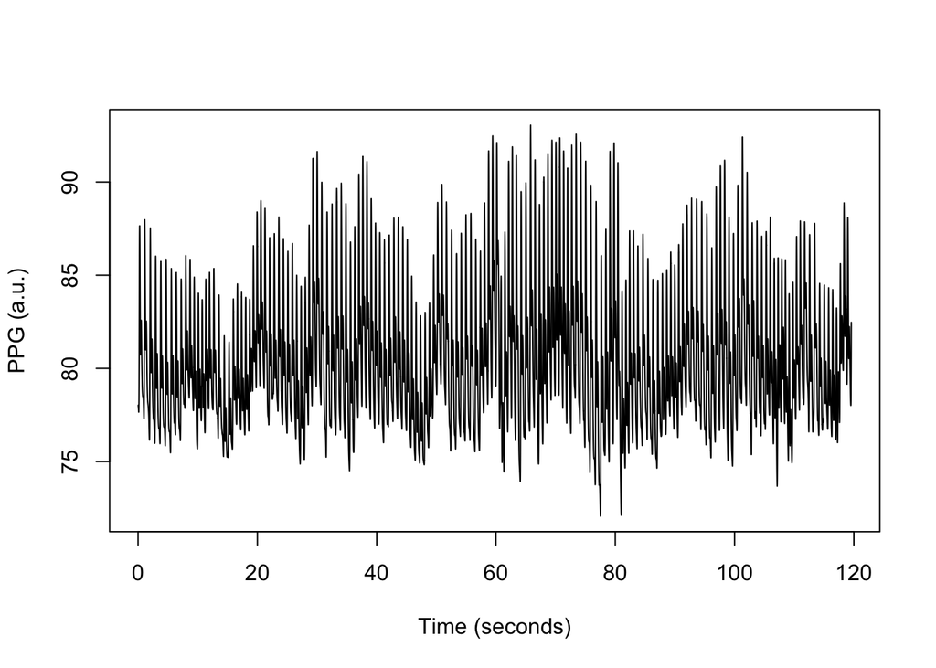

```r
plot((1:length(undetrended))/samplingRate, undetrended, t = "l", xlab = "Time (seconds)", ylab = "PPG (a.u.)")
```

# Extract Spectral Features

If desired, frequency domain features can be extracted from the PPG time series at this point. These include low, medium and high frequency band powers (relative to total power), as well as low to high frequency ratio. Frequency bands are defined according to [Lee et al, 2011](https://pubmed.ncbi.nlm.nih.gov/21693795/).

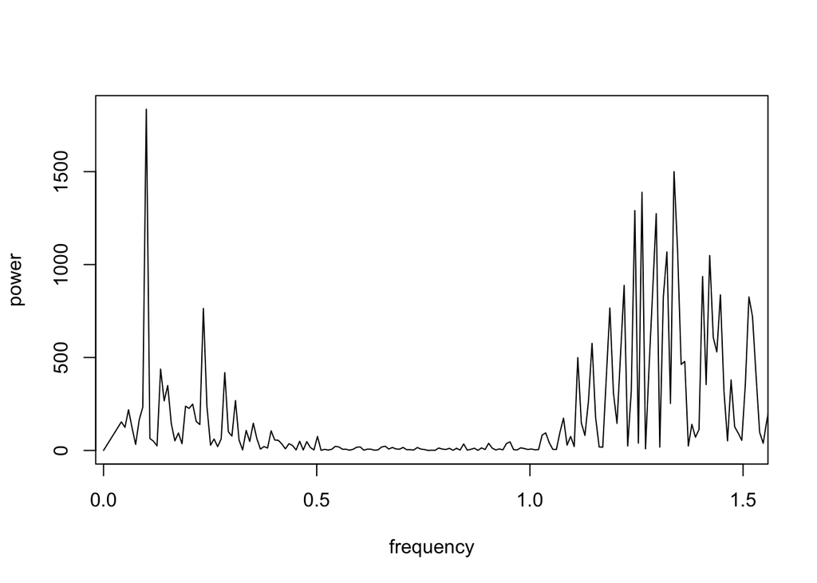

```r
N <- length(undetrended)
xPer <- (1/N)*abs(fft(undetrended)^2)
f <- seq(0,1.0-1/N,by=1/N)
f <- f*samplingRate
spectrum <- data.frame(f, xPer)
point04 <- which(abs(f - 0.04) == min(abs(f - 0.04)))
point08 <- which(abs(f - 0.08) == min(abs(f - 0.08)))
point145 <- which(abs(f - 0.145) == min(abs(f - 0.145)))
point45 <- which(abs(f - 0.45) == min(abs(f - 0.45)))
total_power <- sum(spectrum[point04:point45, 2])
LFNU <- sum(spectrum[point04:point145, 2]) / total_power
MFNU <- sum(spectrum[point08:point145, 2]) / total_power
HFNU <- sum(spectrum[point145:point45, 2]) / total_power
LFHF_ratio <- LFNU / HFNU
spectrum[c(which(1:nrow(spectrum) < point04)), ] <- 0
spectral_features <- list(LFNU, MFNU, HFNU, LFHF_ratio)
plot(spectrum, t = "l", xlim = c(0.04, 1.5), ylim = c(0, max(spectrum$xPer)), xlab = "frequency", ylab = "power")
```

```r
print(LFHF_ratio)
```

```
## [1] 0.7800407
```

# Beat Segmentation

In this section, peaks in the time series are formally identified and used as the basis for segmentation of the time series into individual waveforms.

### Peak Detection

```r
undetrended <- ppg[, 2]
sfunction <- splinefun(1:length(undetrended), undetrended, method = "natural")
deriv1 <- sfunction(seq(1, length(undetrended)), deriv = 1)
spline1 <-  sfunction(seq(1, length(undetrended)), deriv = 0)
splinePoly <- CubicInterpSplineAsPiecePoly(1:length(undetrended), undetrended, "natural")
deriv1Poly <- CubicInterpSplineAsPiecePoly(1:length(undetrended), deriv1, "natural")
inflexX <- solve(splinePoly, b = 0, deriv = 1)
inflexY <- predict(splinePoly, inflexX)
w <- find_w(d1p = deriv1Poly, deriv1 = deriv1, sp = splinePoly, sr = samplingRate, pk_thrshd = pk_thrshd)
```

The identified peaks can then be visualised as found in the first derivative of the time series:

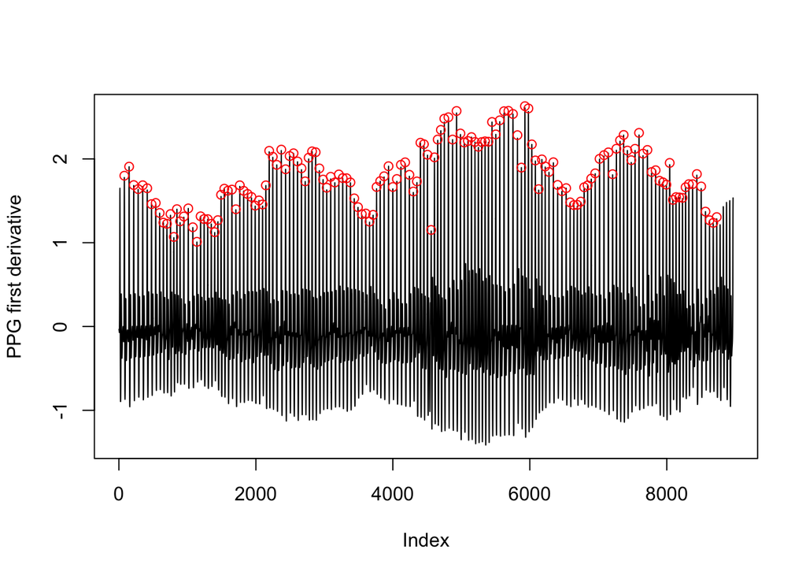

```r
plot(deriv1, t = "l", ylab = "PPG first derivative")
points(w$wX, w$wYD1, col = "red")
```

Note also the y-axis of the first derivative. We can see that 0.8 was an appropriate starting parameter for ‘pk_thrshd’, given all secondary peaks are below this value whilst all primary peaks are above it. When assessing new data, it may be necessary to first run the code up to where the first derivative (deriv1) can be visualised and an appropriate threshold determined.

### Beat Segmentation and cleaning

The time series is then segmented into individual waveforms. Cleaning steps occur pre and post segmentation.

```r
uv <- find_u_v(wx = w$wX, wy = w$wY, d1 = deriv1, d1p = deriv1Poly,
               spline = splinePoly, sr = samplingRate, plot=F)
tmp <- find_o(wx = w$wX, inx = inflexX, iny = inflexY, d1p = deriv1Poly, sp = splinePoly)
inflexX <- tmp[[1]]
inflexY <- tmp[[2]]
o_orig <- tmp[[3]]
tmp <- preclean_wuv(w=w, uv=uv, o=o_orig, samp = samplingRate, sp = spline1, q = F)
w <- tmp[[1]]
uv <- tmp[[2]]
o <- tmp[[3]]
rm(tmp)
baseCor <- baseline(inx = inflexX, iny = inflexY, o = o_orig,
                    dat = undetrended, sp = splinePoly, plot=F)
sfunctionBC <- splinefun(1:length(baseCor), baseCor, method = "natural")
deriv1BC <- sfunctionBC(seq(1, length(baseCor)), deriv = 1)
spline1BC <- sfunctionBC(seq(1, length(baseCor)), deriv = 0)
splinePolyBC <- CubicInterpSplineAsPiecePoly(1:length(baseCor), baseCor, "natural")
deriv1PolyBC <- CubicInterpSplineAsPiecePoly(1:length(baseCor), deriv1BC, "natural")
w$wY <- predict(splinePolyBC, w$wX)
uv$uY <- predict(splinePolyBC, uv$uX)
uv$vY <- predict(splinePolyBC, uv$vX)
wuv <- cbind(w, uv)
tmp <- clean_wuv(wuv = wuv, sp = splinePolyBC, inx = inflexX, o = o,
                 samp = samplingRate, bc = baseCor, q = F)
wuv <- tmp[[1]]
ibi <- tmp[[2]]
oDiff <- tmp[[3]]
rm(tmp, w, uv)
waveLen <- round(median(oDiff)+15)
ppg[, 2] <- baseCor
tmp <- sep_beats(odiff = oDiff, bc = baseCor, samp = samplingRate, wuv = wuv, wvlen = waveLen,
                 ibi=ibi, o=o_orig, inx = inflexX, scale = T, q = F, subset = FALSE, boundaries)
avWave <- tmp[[1]]
pulse <- tmp[[2]]
wuv <- tmp[[3]]
rejects <- tmp[[4]]
rm(tmp)
```

All pulse waveforms can then be aligned and visualised, with the average (mean) waveform overlayed in red:

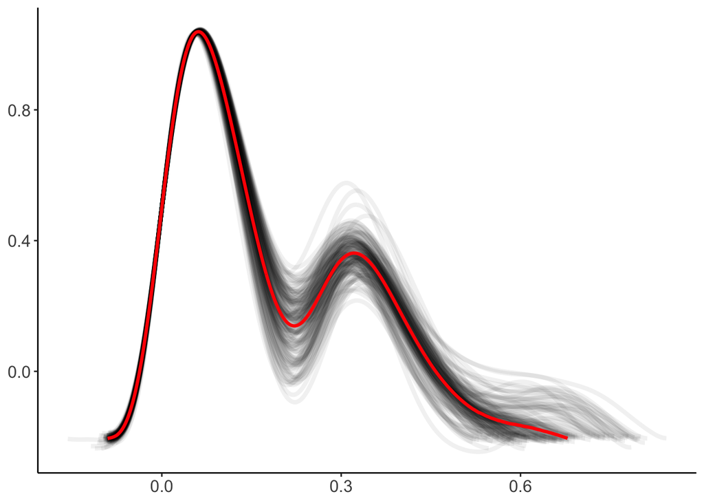

```r
if(plot_aligned_waves == TRUE){
  pulse_stacked <- gather(pulse, key = "wave_ID", value = "values", -c("x"))
  average <- data.frame(seq((-141/(samplingRate*10)),
                            ((waveLen*15 -9)-142)/(samplingRate*10),
                            by = 1/(samplingRate*10)))
  average <- cbind(average, avWave)
  colnames(average)[1] <- "x"
  pl <- ggplot(data = pulse_stacked[-which(is.na(pulse_stacked[, 3])), ],
               aes(x, values, col = wave_ID), col = "black") +
    scale_color_manual(values = rep("black", ncol(pulse))) +
    geom_line(size = 1.5, alpha = ((1/length(wuv$wX)*10)-(1/length(wuv$wX)))) +
    geom_line(data = average[-which(is.na(average[, 2])), ],
              aes(x, avWave), size = 1.125, color = "red") +
    theme(legend.position = "none") + labs( y= "PPG Output", x = "Time (Seconds)") +
    theme(panel.grid.major = element_blank(), panel.grid.minor = element_blank(),
          panel.background = element_blank(), axis.line = element_line(colour = "black"),
          axis.title = element_blank(),
          axis.text = element_text(size = 12))
  print(pl)
}
```

# The Hybrid Excess and Decay (HED) Model

Prior to running the HED model, starting parameters must be estimated. The starting parameter for ‘decay rate’ (i.e. config.rate) is defined first. 0.99 is recommended for canonical waveforms, lower values may be required for non-canonical waveforms e.g class 3 or above (for description of classes, see figure 1 of [Tigges et al, 2016](https://www.degruyter.com/document/doi/10.1515/cdbme-2016-0046/html?lang=en)):

```r
config.rate = 0.99
lab.time = "time (s)"
lab.ppg = "Detrended"
const.pi = 3.1415926535897932384626433
```

As the HED model runs it will generate plots of fitted waveforms. It is worth viewing these to assess the overall quality and plausability of fits. For the sake of space, however, we will only plot two here by ensuring the ‘GGplotFits’ function only runs once. ‘PlotFits’ (commented out in the code below) can also be used for plotting in base R, and is somewhat less expensive.

```r
plotfitsgo = TRUE
```

Running HED (this is the most computationally demanding section of the pipeline and may therefore take some time, especially when all waveforms are modelled).

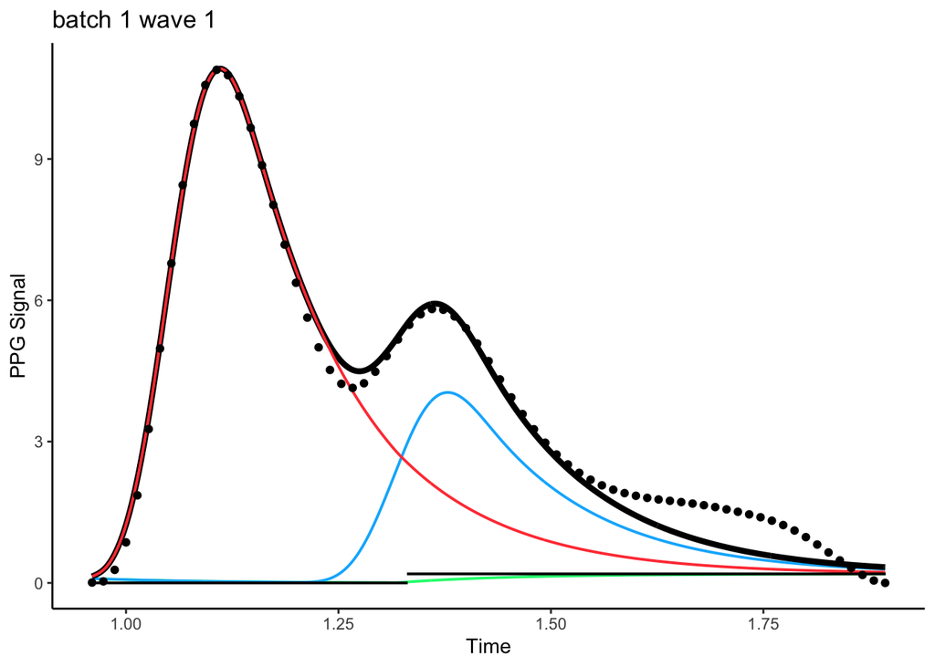

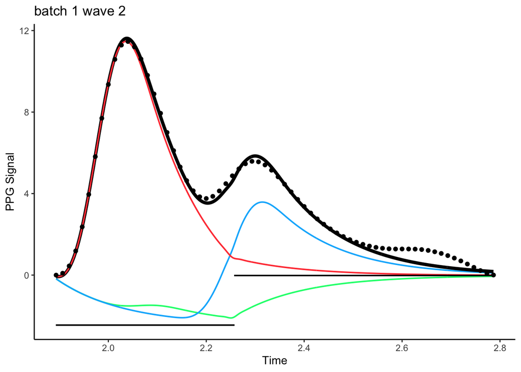

```r
if(run_hed == TRUE){

  beat <-  ppg[round(inflexX[wuv$o2]), 1]
  nBeats <- length(beat)
  beat <- data.frame(
    beat = beat,
    dt = (1:nBeats)*0.0
  )
  beat <- AddOutput(beat)
  if(all_beats == T){
    batch_number <- floor(nrow(beat)/beats_in)
    remainder <- nrow(beat) - (batch_number*beats_in)
  }

  ppg$Baseline = 1:nrow(ppg) * 0
  ppg$Excess   = 1:nrow(ppg) * 0
  ppg$Residue  = 1:nrow(ppg) * 0

  temp <- FindStartParams(batch_number, beats_in, beat, ppg, gs = model2.GetSegment,
                          e = model2.Excess, sep = model2.SubtractExcessPeak,
                          o_points = inflexX[o_orig], wuv = wuv, inflexX = inflexX, all_beats)
  beat <- temp[[1]]
  ppg <- temp[[2]]
  rm(temp)

  beat_orig <- beat
  fit_check <- list()
  for(k in 1:(batch_number+1)){

    if(all_beats == TRUE){
      if(k == batch_number+1){
        if(remainder == 0){break}
        beat <- beat_orig[(((k-1)*beats_in) + 1 ):(((k-1)*beats_in) + remainder), ]
        beats_in <- remainder
        w <- wuv$wX[(((k-1)*beats_in) + 1 ):(((k-1)*beats_in) + remainder)]
      }else{
        beat <- beat_orig[((k*beats_in)-(beats_in-1)):(k*beats_in), ]
        w <- wuv$wX[((k*beats_in)-(beats_in-1)):(k*beats_in)]
      }
    }else{
      if(k == batch_number+1){break}
      beat <- beat_orig[((k*beats_in)-(beats_in-1)):(k*beats_in), ]
      w <- wuv$wX[((k*beats_in)-(beats_in-1)):(k*beats_in)]
    }

    w <- w / samplingRate
    renal_param <- median(beat$NTime)
    dias_param <- median(beat$DTime)
    sys_time <- beat$STime
    par <- as.numeric(beat[1,5:16])
    beat_start <- beat[, 3]
    beat_end <- beat[, 4]
    beat_vector <- list(beats_in, beat_start, beat_end)

    for(i in 1:4){
      if(i == 1){new_beat <- beat}
      within_params <- FindWithinParams(beats_in, ppg, beat = new_beat, gs = model2.GetSegment,
                                        fp = model2.FixParams3, ms = simplex.MakeSimplex3,
                                        m2 = model2.ChiSq3, beat_vector = beat_vector,
                                        renal_param = renal_param, dias_param = dias_param,
                                        sys_time = sys_time, w = w)
      across_params <- simplex.MakeSimplex2(data=ppg, param = par, f = model2.ChiSq3,
                                            inScale = 0.1, beat_vector = beat_vector,
                                            beat = new_beat, renal_param = renal_param,
                                            dias_param = dias_param, sys_time = sys_time, w = w)
      mat <- make_matrix(across_params, within_params)
      sim <- simplex.Run2(data = ppg, simplexParam = mat, f = model2.ChiSq3, optional=NULL,
                          beat_vector = beat_vector, renal_param = renal_param,
                          dias_param = dias_param, sys_time = sys_time, ms = simplex_iterations,
                          w = w, run = c("run", i))
      output <- extractOutput(beats_in, sim)
      fixed <- FixOutput(beats_in, beat = new_beat, ppg, gs = model2.GetSegment,
                         fp = model2.FixParams3, across = output[[1]], within = output[[2]],
                         sys_time = sys_time)
      new_beat <- UpdateBeat(beats_in, beat, fixed)
      new_beat <- FixBaseline(new_beat, f = model2.ChiSq4, renal_param, dias_param, sys_time, w)
    }


    fit_check[[k]] <- model2.ChiSq4(data = ppg, params = NULL, beats = beat_vector,
                                    beat = new_beat, a = sim[1, ], plot = FALSE,
                                    renal_param = renal_param, dias_param = dias_param,
                                    sys_time = sys_time, w = w)

    beat2 <- new_beat
    colnames(beat2) <- colnames(beat)
    beat2 <- beat2[, -c(1:4)]

    # PlotFits(beats_in, ppg, beat2, gs = model2.GetSegment, rb = model2.Rebuild2)

     if (plotfitsgo == T){
     GGplotFits(beats_in, ppg, beat2, gs = model2.GetSegment, rb = model2.Rebuild2,
     run = 1, pr = 1, p = T, iso = F)
     plotfitsgo <- FALSE
     }

    if(k == 1){beat_final <- beat2}else{beat_final <- rbind(beat_final, beat2)}

  }
}
```

# Morphological feature extraction

First fiducial points (OSND) are identified on each individual waveform.

```r
polyWave <- list()
for(i in 2:ncol(pulse)){
  polyWave[[i-1]] <-CubicInterpSplineAsPiecePoly(pulse$x, pulse[, i], "natural")
}
tmp <- diast_pk(avw = avWave, sr = samplingRate, scale = T)
dPeak <- tmp[1]
xShift <- tmp[2]
rm(tmp)
osnd <- osnd_of_average(avWave, dp = dPeak, diff = 0, sr = samplingRate, plot = F)
if(dPeak == 5*samplingRate){
  dPeak <- osnd$x[4]*1.2
}
if((osnd$x[4]-osnd$x[3]) < 1.5 & (osnd$x[4]-osnd$x[3]) > 0){
  dPeak <- dPeak*0.95
  osnd <- osnd_of_average(avWave, dp = dPeak, diff = 0, sr = samplingRate, plot = FALSE)
}
scale <- 1
osnd_all <- list()
for(i in 2:ncol(pulse)){
  wavi <- pulse[, i][!is.na(pulse[, i])]
  if(scale == 1){
    xShift2 <- (which(abs(wavi - 0.5) == min(abs(wavi - 0.5))))
  }else{
    xShift2 <- which.min(abs(wavi))
  }
  diff <- xShift - xShift2
  dpa <- dPeak - diff
  osnd_all[[i-1]] <- osnd_of_average(aw = wavi, dp = dpa, diff = diff,
                                     sr = samplingRate, plot = F)
}
```

These can then be plotted against the average waveform:

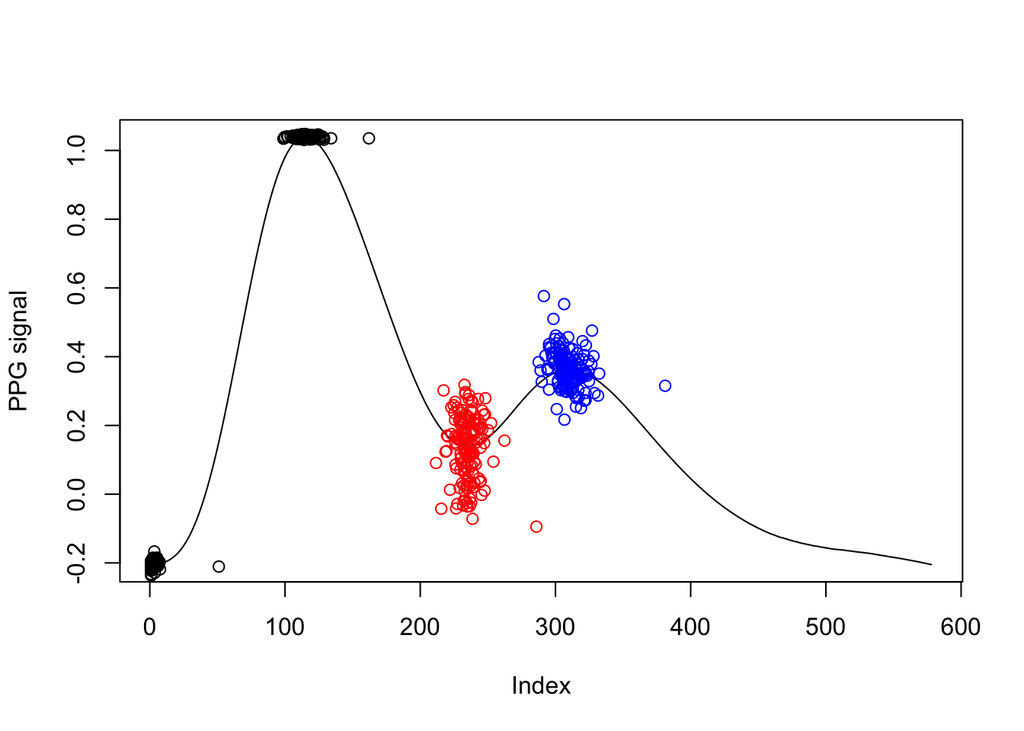

```r
if(plot_osnd == TRUE){
  plot(avWave[!is.na(avWave)], type = "l", ylab = "PPG signal") + for(i in 1:length(osnd_all)){
    points(osnd_all[[i]][4, 1], osnd_all[[i]][4, 2], col = "blue")
    points(osnd_all[[i]][3, 1], osnd_all[[i]][3, 2], col = "red")
    points(osnd_all[[i]][2, 1], osnd_all[[i]][2, 2])
    points(osnd_all[[i]][1, 1], osnd_all[[i]][1, 2])
  }
}
```

Then features derived from fiducial points (e.g. augmentation index) can be derived:

```r
for(i in 1:length(osnd_all)){
  osnd_all[[i]]$y <- osnd_all[[i]]$y - osnd_all[[i]]$y[1]
}
features <- feature_extract(oa = osnd_all, p = pulse, pw = polyWave)
```

# Outputs

Finally, the outputs generated across the pipeline are arranged into the ‘AllOutputs’ list:

```r
if(run_hed == TRUE){
  beat_final <- cbind(beat_orig[1:nrow(beat_final), 1:4], beat_final)
  osnd_fits <- osnd_fit(beat_final, ppg, plot = F)
}
if(run_hed == FALSE){
  fit_check <- list(c(1:100), c(1:100), c(1:100))
  beat_final <- data.frame(1:nrow(features))
  beat_orig <- data.frame(1:nrow(features))
  osnd_fits <- list(1:100)
  }
temp <- ArrangeOutputs(beat_final, beat_orig, features, pulse, fit_check)
nBeats <- ncol(pulse) - 1
AllOutputs <- list(nBeats, ibi, rejects, pulse, polyWave, osnd_all, avWave, osnd, temp[[2]], temp[[1]], temp[[3]], osnd_fits, spectral_features)
```

The key to the output list is as follows:

```r
# [[1]] == nBeats                         Number of waveforms in sample
# [[2]] == ibi                            Inter-beat intervals (note pre-interpolation)
# [[3]] == rejects                        Rejected beats, arranged according to reason for exclusion (see Readme)
# [[4]] == pulse                          Individual waveforms in the sample (discrete form)
# [[5]] == polyWave                       Individual waveforms in the sample (polynomial spline form)
# [[6]] == osnd_all                       OSND points of individual waves
# [[7]] == avWave                         Average waveform of the sample
# [[8]] == osnd (of average)              OSND points of the average waveform
# [[9]] == features                       Morphological features derived from OSND points (see supplementary material)
# [[10]] == beat_final                    Model parameter Outputs
# [[11]] == fit_check                     Goodness of fit Measures (ChiSq, Max error, NRMSE, aNRMSE)
# [[12]] == osnd_fits                     Error values (x and y) in recapitulation of OSND points
# [[13]] == spectral_features             Spectral features
```

# Exploring Outputs

Once the pipeline has run, outputs can be examined in a number of ways. Below are some examples of visualisations that may be of interest. Outputs that prove to be informative could also be used as the basis for classification models.

### Interbeat intervals

An interbeat interval time series is shown with the following plot. Note that due to cleaning and removal of waveforms, caution should be taken when interpreting: intervals are not necessarily between consecutive waveforms in all cases. Nonetheless, an approximation to heart rate variability across the time series can be extracted by taking the standard deviation of interbeat intervals (akin to SDNN) after removal of outliers (i.e. implausibly long intervals).

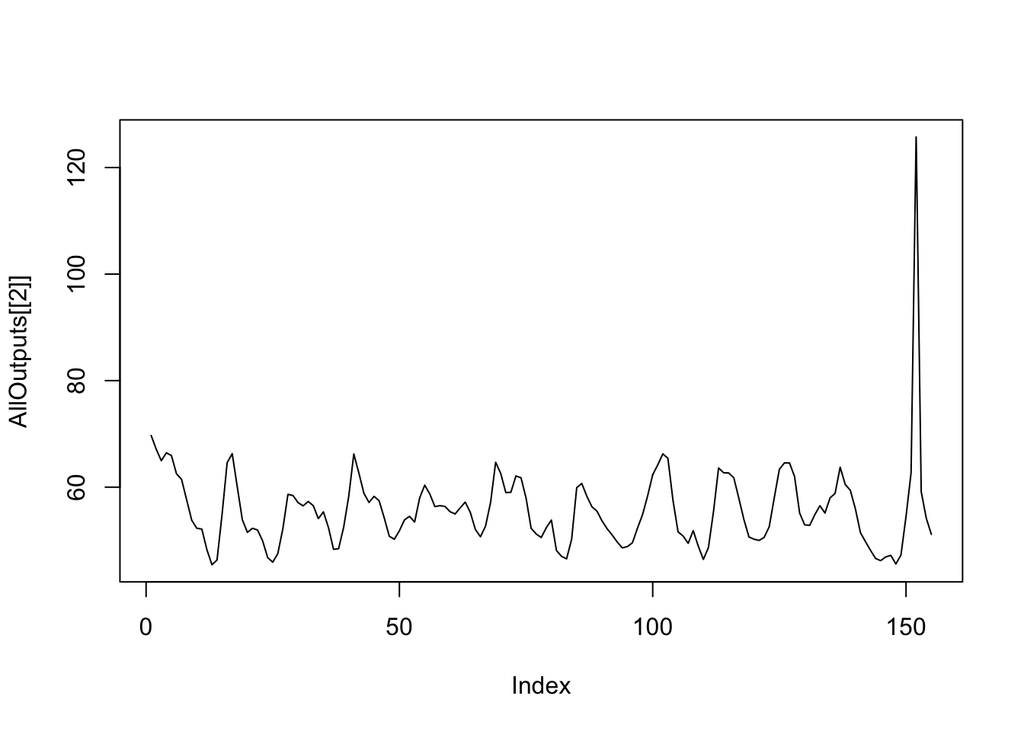

```r
plot(AllOutputs[[2]], t = "l")
```

In this plot we see a single outlier value, likely due to an interval between non-consecutive peaks. It should be removed before calculating heart (pulse) rate variability:

```r
ibis <- which(AllOutputs[[2]] < 80)
sdrr <- sd(ibis)
print(sdrr)
```

```
## [1] 44.63347
```

### Morphological features

Morphological (descriptive / fiducial point) features are outputted as a dataframe.

```r
print(head(AllOutputs[[9]]))
```

```
##          s_vals    n_vals    d_vals  np_ratio      ppt  max_amp      auc
## wave_1 1.246927 0.4735642 0.6661865 0.3797851 191.7443 1.042226 161.4207
## wave_2 1.244725 0.4078287 0.6067281 0.3276456 194.6185 1.039695 139.8187
## wave_3 1.239914 0.3649262 0.5967934 0.2943157 193.4609 1.039425 129.1458
## wave_4 1.242800 0.3768428 0.5978092 0.3032208 195.2545 1.037457 127.9314
## wave_5 1.249569 0.3688530 0.5910757 0.2951841 197.6569 1.039447 133.0996
## wave_6 1.236236 0.3529186 0.5947594 0.2854784 198.1846 1.037960 130.8241
##            auc_s   l ipa_ratio   pn_time nt_ratio        ai       aai       ct
## wave_1 120.59154 696  2.418919 0.1686031 2.090757 0.5342627 0.4657373 107.5163
## wave_2  99.39023 674  3.793464 0.1788935 1.930849 0.4874394 0.5125606 109.0521
## wave_3  89.49595 650  5.094466 0.1833811 1.866460 0.4813184 0.5186816 106.8519
## wave_4  88.57306 665  5.207931 0.1791965 1.920872 0.4810181 0.5189819 108.0005
## wave_5  94.01304 662  4.371133 0.1841498 1.852692 0.4730235 0.5269765 109.8038
## wave_6  91.08281 625  4.809487 0.1940284 1.730219 0.4811052 0.5188948 106.9110
```

Individual feature time series may show interesting dynamic behaviour across the time series, such as the notch to peak ratio:

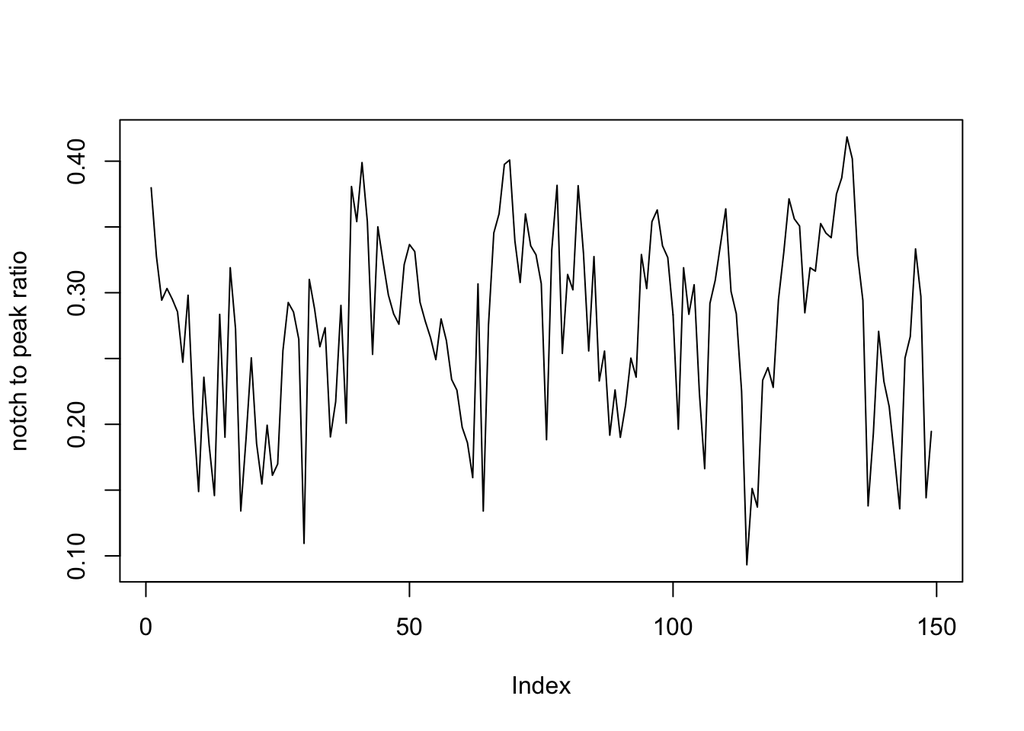

```r
plot(AllOutputs[[9]]$np_ratio, t = "l", ylab = "notch to peak ratio")
```

### HED Model Performance

#### Goodness of fit

We can assess goodness of fit across the sample of waveforms by visualising NRMSE values for each fitted waveform. In this case the median NRMSE is 0.89 (2dp). These results tend to be negatively skewed.

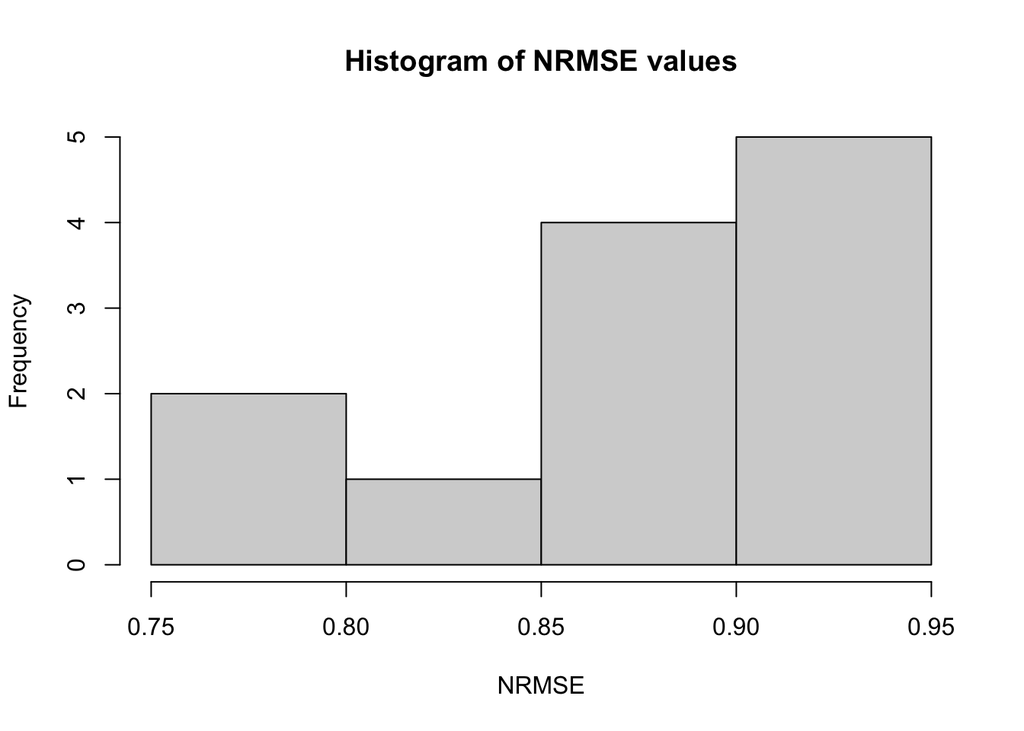

```r
hist(AllOutputs[[11]][[3]], main = "Histogram of NRMSE values", xlab = "NRMSE")
```

```r
print(median(AllOutputs[[11]][[3]]))
```

```
## [1] 0.8904117
```

### HED model parameter outputs

Parameter outputs of the HED Model are outputted as a single dataframe:

```r
print(head(AllOutputs[[10]][, -c(1:4)]))
```

```
##         Baseline   Baseline2    STime SAmplitude    SWidth     DTime DAmplitude
## wave_1  0.000000  0.19065883 1.064325   2.211807 0.2767719 0.2663035  0.8010106
## wave_2 -2.454678 -0.02030904 1.991308   2.669379 0.2767719 0.2663035  1.0297469
## wave_3 -1.769862 -1.01903088 2.895695   2.534642 0.2683447 0.2627901  0.8737928
## wave_4 -1.519960 -0.01508095 3.750256   2.283079 0.2683447 0.2627901  0.6912391
## wave_5 -3.802596 -1.21414194 4.642769   2.667606 0.4135918 0.2638976  1.4022980
## wave_6 -2.033325  0.13024259 5.518396   2.232001 0.4135918 0.2638976  0.9252800
##           DWidth      NTime NAmplitude NWidth config.rate
## wave_1 0.2801949 0.08000000  0.0000000   0.25   0.9067335
## wave_2 0.2801949 0.08000000  0.1040440   0.25   0.9067335
## wave_3 0.3270026 0.08000000  0.0000000   0.10   0.8993313
## wave_4 0.3270026 0.08000000  0.1552562   0.10   0.8993313
## wave_5 0.4461021 0.06666667  0.2977730   0.10   0.8558772
## wave_6 0.4461021 0.06666667  0.2616082   0.10   0.8558772
```

# End

This is the end of the tutorial. If there are any questions please do refer to the [ReadMe](https://github.com/stw32/PulseWaveform). To apply the pipeline to your own PPG data, the [general purpose script](https://github.com/stw32/PulseWaveform/blob/main/Scripts/GeneralPurposeScript) containing the code above is available and can be altered as required for multiple time series / individuals / groups.